# 04 Relationships between words: n-grams and correlations

H. David Shea

30 Jul 2021

Now, we focus on relationships between words in a document - which words tend to occur together (immediate vicinity) or co-occur in the same document. An ‘n-gram’ is a token of “adjacent words”.

## Tokenizing by n-gram

### Counting and filtering n-grams

```r
austen_bigrams <- austen_books() %>%
    unnest_tokens(bigram, text, token = "ngrams", n = 2)

austen_bigrams %>%
    slice_sample(n = 10) %>%
    kable()
```

| book | bigram |
| --- | --- |
| Emma | another carriage |
| Persuasion | what might |
| Pride & Prejudice | from *you* |
| Mansfield Park | my uncle |
| Persuasion | views of |
| Sense & Sensibility | utterance and |
| Northanger Abbey | such as |
| Emma | book one |
| Sense & Sensibility | and sometimes |
| Emma | there always |

```r
austen_bigrams %>%
    count(bigram, sort = TRUE) %>%
    slice_max(n, n = 10) %>%
    kable()
```

| bigram | n |
| --- | --- |
| NA | 12242 |
| of the | 2853 |
| to be | 2670 |
| in the | 2221 |
| it was | 1691 |
| i am | 1485 |
| she had | 1405 |
| of her | 1363 |
| to the | 1315 |
| she was | 1309 |

```r
bigrams_separated <- austen_bigrams %>%
    separate(bigram, c("word1", "word2"), sep = " ")

bigrams_filtered <- bigrams_separated %>%
    filter(!word1 %in% stop_words$word) %>%
    filter(!word2 %in% stop_words$word)

# new bigram counts:
bigram_counts <- bigrams_filtered %>%
    count(word1, word2, sort = TRUE)

bigram_counts %>%
    slice_max(n, n = 10) %>%
    kable()
```

| word1 | word2 | n |
| --- | --- | --- |
| NA | NA | 12242 |
| sir | thomas | 266 |
| miss | crawford | 196 |
| captain | wentworth | 143 |
| miss | woodhouse | 143 |
| frank | churchill | 114 |
| lady | russell | 110 |
| sir | walter | 108 |
| lady | bertram | 101 |
| miss | fairfax | 98 |

```r
bigrams_united <- bigrams_filtered %>%
    unite(bigram, word1, word2, sep = " ")

bigrams_united %>%
    slice_sample(n = 10) %>%
    kable()
```

| book | bigram |
| --- | --- |
| Emma | miss woodhouse |
| Emma | NA NA |
| Pride & Prejudice | NA NA |
| Mansfield Park | green geese |
| Sense & Sensibility | NA NA |
| Emma | wait till |
| Sense & Sensibility | desperately enraged |
| Mansfield Park | poor susan |
| Pride & Prejudice | NA NA |
| Mansfield Park | NA NA |

```r
austen_books() %>%
    unnest_tokens(trigram, text, token = "ngrams", n = 3) %>%
    separate(trigram, c("word1", "word2", "word3"), sep = " ") %>%
    filter(!word1 %in% stop_words$word,!word2 %in% stop_words$word,!word3 %in% stop_words$word) %>%
    count(word1, word2, word3, sort = TRUE) %>%
    slice_max(n, n = 10) %>%
    kable()
```

| word1 | word2 | word3 | n |
| --- | --- | --- | --- |
| NA | NA | NA | 13260 |
| dear | miss | woodhouse | 20 |
| miss | de | bourgh | 17 |
| lady | catherine | de | 11 |
| poor | miss | taylor | 11 |
| sir | walter | elliot | 10 |
| catherine | de | bourgh | 9 |
| dear | sir | thomas | 8 |
| replied | miss | crawford | 7 |
| sir | william | lucas | 7 |
| ten | thousand | pounds | 7 |

### Analyzing bigrams

```r
bigrams_filtered %>%
  filter(word2 == "street") %>%
  count(book, word1, sort = TRUE) %>%
    slice_max(n, n = 10) %>%
    kable(caption = "Most Common 'Street' Names in Jane Austen's Novels")
```

Most Common ‘Street’ Names in Jane Austen’s Novels

| book | word1 | n |
| --- | --- | --- |
| Sense & Sensibility | harley | 16 |
| Sense & Sensibility | berkeley | 15 |
| Northanger Abbey | milsom | 10 |
| Northanger Abbey | pulteney | 10 |
| Mansfield Park | wimpole | 9 |
| Pride & Prejudice | gracechurch | 8 |
| Persuasion | milsom | 5 |
| Sense & Sensibility | bond | 4 |
| Sense & Sensibility | conduit | 4 |
| Persuasion | rivers | 4 |

```r
bigram_tf_idf <- bigrams_united %>%
  count(book, bigram) %>%
  bind_tf_idf(bigram, book, n) %>%
  arrange(desc(tf_idf))

bigram_tf_idf %>%
    slice_max(tf_idf, n = 10) %>%
    kable(caption = "tf-idf or Bigrams in Jane Austen's Novels")
```

tf-idf or Bigrams in Jane Austen’s Novels

| book | bigram | n | tf | idf | tf_idf |
| --- | --- | --- | --- | --- | --- |
| Mansfield Park | sir thomas | 266 | 0.0244238 | 1.79176 | 0.0437616 |
| Persuasion | captain wentworth | 143 | 0.0232143 | 1.79176 | 0.0415944 |
| Mansfield Park | miss crawford | 196 | 0.0179965 | 1.79176 | 0.0322454 |
| Persuasion | lady russell | 110 | 0.0178571 | 1.79176 | 0.0319957 |
| Persuasion | sir walter | 108 | 0.0175325 | 1.79176 | 0.0314140 |
| Emma | miss woodhouse | 143 | 0.0128817 | 1.79176 | 0.0230809 |
| Northanger Abbey | miss tilney | 74 | 0.0127829 | 1.79176 | 0.0229038 |
| Sense & Sensibility | colonel brandon | 96 | 0.0114572 | 1.79176 | 0.0205286 |
| Sense & Sensibility | sir john | 94 | 0.0112185 | 1.79176 | 0.0201009 |
| Emma | frank churchill | 114 | 0.0102693 | 1.79176 | 0.0184002 |

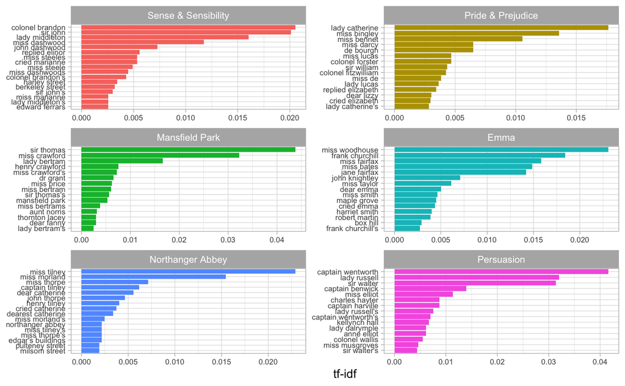

Bigrams with the highest tf-idf from each Jane Austen novel

```r
bigram_tf_idf %>%
    group_by(book) %>%
    slice_max(tf_idf, n = 15) %>%
    ungroup() %>%
    ggplot(aes(tf_idf, fct_reorder(bigram, tf_idf), fill = book)) +
    geom_col(show.legend = FALSE) +
    facet_wrap( ~ book, ncol = 2, scales = "free") +
    labs(x = "tf-idf", y = NULL) +
    theme_light() +
    theme(axis.text = element_text(size = 7))
```

“There are advantages and disadvantages to examining the tf-idf of bigrams rather than individual words. Pairs of consecutive words might capture structure that isn’t present when one is just counting single words, and may provide context that makes tokens more understandable.”

“However, the per-bigram counts are also sparser: a typical two-word pair is rarer than either of its component words. Thus, bigrams can be especially useful when you have a very large text dataset.”

### Using bigrams to provide context in sentiment analysis

Bigrams can help get at true context for terms like ‘not happy’, for instance.

```r
bigrams_separated %>%
    filter(word1 == "not") %>%
    count(word1, word2, sort = TRUE) %>%
    slice_max(n, n = 10) %>%
    kable(caption = "Words preceeded by 'not' in in Jane Austen's Novels")
```

Words preceeded by ‘not’ in in Jane Austen’s Novels

| word1 | word2 | n |
| --- | --- | --- |
| not | be | 580 |
| not | to | 335 |
| not | have | 307 |
| not | know | 237 |
| not | a | 184 |
| not | think | 162 |
| not | been | 151 |
| not | the | 135 |
| not | at | 126 |
| not | in | 110 |

```r
AFINN <- get_sentiments("afinn")

not_words <- bigrams_separated %>%
    filter(word1 == "not") %>%
    inner_join(AFINN, by = c(word2 = "word")) %>%
    count(word2, value, sort = TRUE)

not_words %>%
    slice_max(n, n = 10) %>%
    kable(caption = "Sentiment value of words preceeded by 'not' in in Jane Austen's Novels")
```

Sentiment value of words preceeded by ‘not’ in in Jane Austen’s Novels

| word2 | value | n |
| --- | --- | --- |
| like | 2 | 95 |
| help | 2 | 77 |
| want | 1 | 41 |
| wish | 1 | 39 |
| allow | 1 | 30 |
| care | 2 | 21 |
| sorry | -1 | 20 |
| leave | -1 | 17 |
| pretend | -1 | 17 |
| worth | 2 | 17 |

We can calculater (and visualize) the sentiment impact of words that contribute in the ‘wrong’ direction to sentiment. Here `contribution` is the sentiment value of the word times the number of times the word appeared in the text preceded by ‘not’.

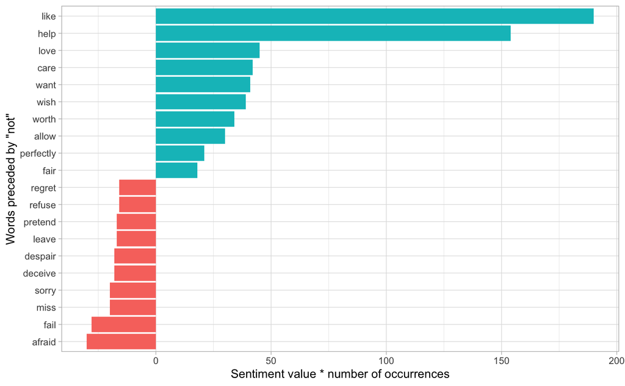

Words preceded by ‘not’ that had the greatest contribution to sentiment values, in either a positive or negative direction

```r
not_words %>%
    mutate(contribution = n * value) %>%
    arrange(desc(abs(contribution))) %>%
    head(20) %>%
    mutate(word2 = reorder(word2, contribution)) %>%
    ggplot(aes(n * value, word2, fill = n * value > 0)) +
    geom_col(show.legend = FALSE) +
    labs(x = "Sentiment value * number of occurrences",
         y = "Words preceded by \"not\"") +
    theme_light()
```

We can expand to more ‘negated words’ beyond just ‘not’.

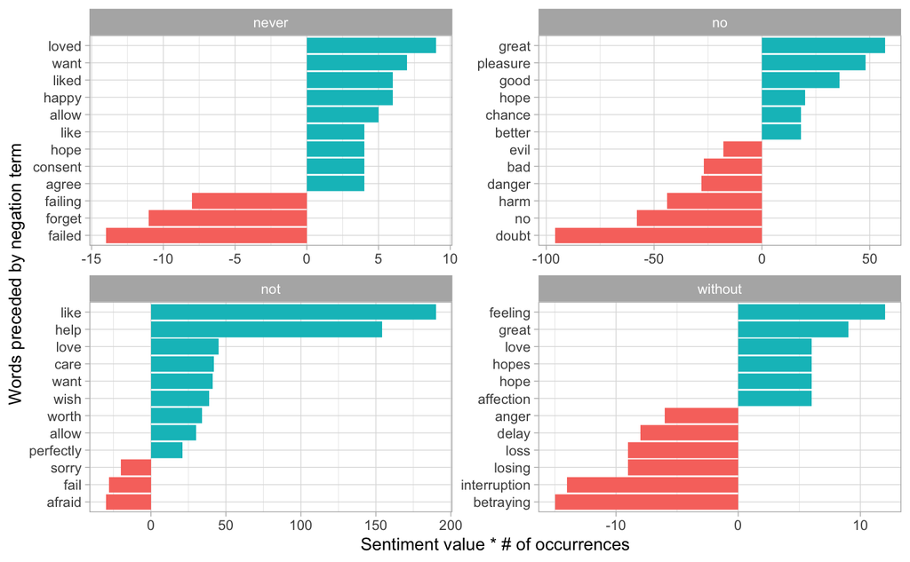

Most common positive or negative words to follow negations such as ‘never’, ‘no’, ‘not’, and ‘without’

```r
negation_words <- c("not", "no", "never", "without")

negated_words <- bigrams_separated %>%
    filter(word1 %in% negation_words) %>%
    inner_join(AFINN, by = c(word2 = "word")) %>%
    count(word1, word2, value, sort = TRUE)

negated_words %>%
    mutate(contribution = n * value,
           word2 = reorder(paste(word2, word1, sep = "__"), contribution)) %>%
    group_by(word1) %>%
    slice_max(abs(contribution), n = 12, with_ties = FALSE) %>%
    ggplot(aes(word2, contribution, fill = n * value > 0)) +
    geom_col(show.legend = FALSE) +
    facet_wrap( ~ word1, scales = "free") +
    scale_x_discrete(
        labels = function(x)
            gsub("__.+$", "", x)
    ) +
    xlab("Words preceded by negation term") +
    ylab("Sentiment value * # of occurrences") +
    coord_flip() +
    theme_light()
```

### Visualizing a network of bigrams with `ggraph`

```r
bigram_counts %>%
    slice_max(n, n = 10) %>%
    kable()
```

| word1 | word2 | n |
| --- | --- | --- |
| NA | NA | 12242 |
| sir | thomas | 266 |
| miss | crawford | 196 |
| captain | wentworth | 143 |
| miss | woodhouse | 143 |
| frank | churchill | 114 |
| lady | russell | 110 |
| sir | walter | 108 |
| lady | bertram | 101 |
| miss | fairfax | 98 |

```r
bigram_graph <- bigram_counts %>%
    filter(n > 20) %>%
    graph_from_data_frame()
bigram_graph
```

```
#> IGRAPH c44a0f8 DN-- 86 71 --
#> + attr: name (v/c), n (e/n)
#> + edges from c44a0f8 (vertex names):
#>  [1] NA      ->NA         sir     ->thomas     miss    ->crawford
#>  [4] captain ->wentworth  miss    ->woodhouse  frank   ->churchill
#>  [7] lady    ->russell    sir     ->walter     lady    ->bertram
#> [10] miss    ->fairfax    colonel ->brandon    sir     ->john
#> [13] miss    ->bates      jane    ->fairfax    lady    ->catherine
#> [16] lady    ->middleton  miss    ->tilney     miss    ->bingley
#> [19] thousand->pounds     miss    ->dashwood   dear    ->miss
#> [22] miss    ->bennet     miss    ->morland    captain ->benwick
#> + ... omitted several edges
```

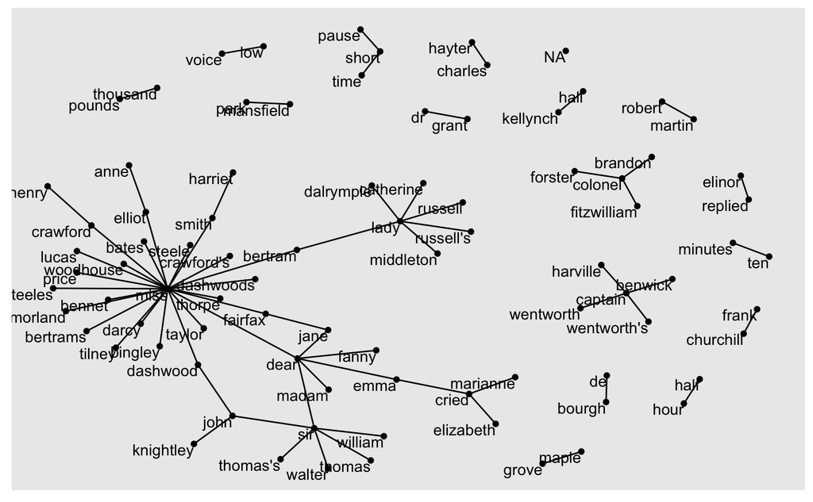

Common bigrams in Jane Austen’s novels, showing those that occurred more than 20 times and where neither word was a stop word

```r
set.seed(2017)

ggraph(bigram_graph, layout = "fr") +
    geom_edge_link() +
    geom_node_point() +
    geom_node_text(aes(label = name), vjust = 1, hjust = 1)
```

Note in the graph that proper title (“miss”, “sir”, etc.) are common centers of nodes. We also see common short phrases like ‘half hour’ and ‘maple grove’.

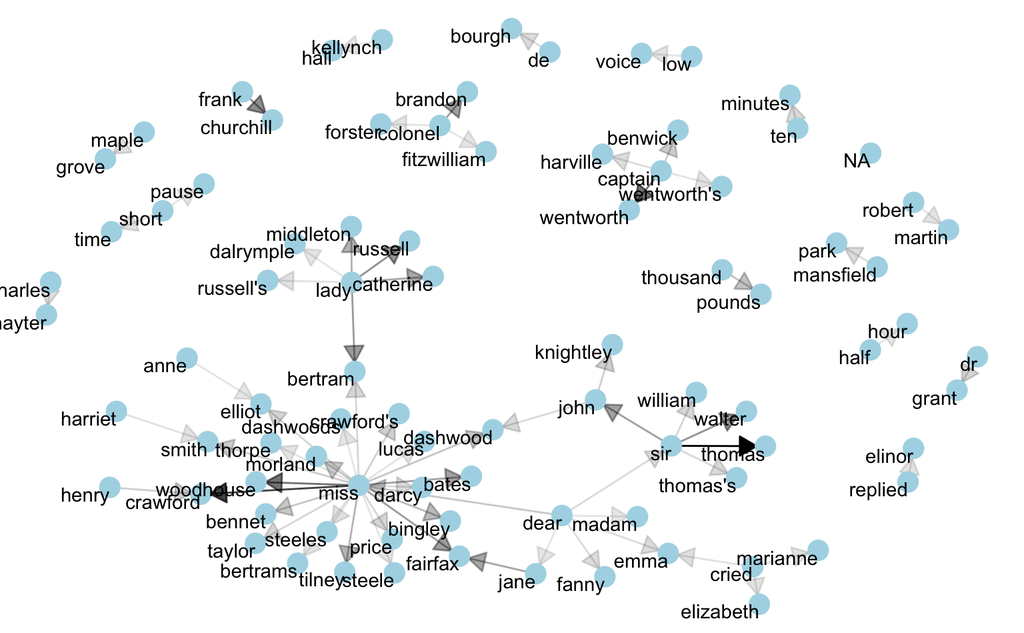

Common bigrams in Jane Austen’s novels, with some polishing

```r
set.seed(2020)

a <- grid::arrow(type = "closed", length = unit(.15, "inches"))

ggraph(bigram_graph, layout = "fr") +
    geom_edge_link(
        aes(edge_alpha = n),
        show.legend = FALSE,
        arrow = a,
        end_cap = circle(.07, 'inches')
    ) +
    geom_node_point(color = "lightblue", size = 5) +
    geom_node_text(aes(label = name), vjust = 1, hjust = 1) +
    theme_void()
```

“Note that this is a visualization of a Markov chain, a common model in text processing. In a Markov chain, each choice of word depends only on the previous word. In this case, a random generator following this model might spit out “dear”, then “sir”, then “william/walter/thomas/thomas’s”, by following each word to the most common words that follow it. To make the visualization interpretable, we chose to show only the most common word to word connections, but one could imagine an enormous graph representing all connections that occur in the text."

### Visualizing bigrams in other texts

First, some useful shortcut functions.

```r
count_bigrams <- function(dataset, .stop_words = stop_words) {
    dataset %>%
        unnest_tokens(bigram, text, token = "ngrams", n = 2) %>%
        separate(bigram, c("word1", "word2"), sep = " ") %>%
        filter(!word1 %in% .stop_words$word,!word2 %in% .stop_words$word) %>%
        count(word1, word2, sort = TRUE)
}

visualize_bigrams <- function(bigrams) {
    set.seed(2016)
    a <- grid::arrow(type = "closed", length = unit(.15, "inches"))

    bigrams %>%
        graph_from_data_frame() %>%
        ggraph(layout = "fr") +
        geom_edge_link(aes(edge_alpha = n),
                       show.legend = FALSE,
                       arrow = a) +
        geom_node_point(color = "lightblue", size = 5) +
        geom_node_text(aes(label = name), vjust = 1, hjust = 1) +
        theme_void()
}
```

Visualizing the bigrams in the King James Version of the bible (ID = 10) from [*Project Gutenberg*](https://www.gutenberg.org).

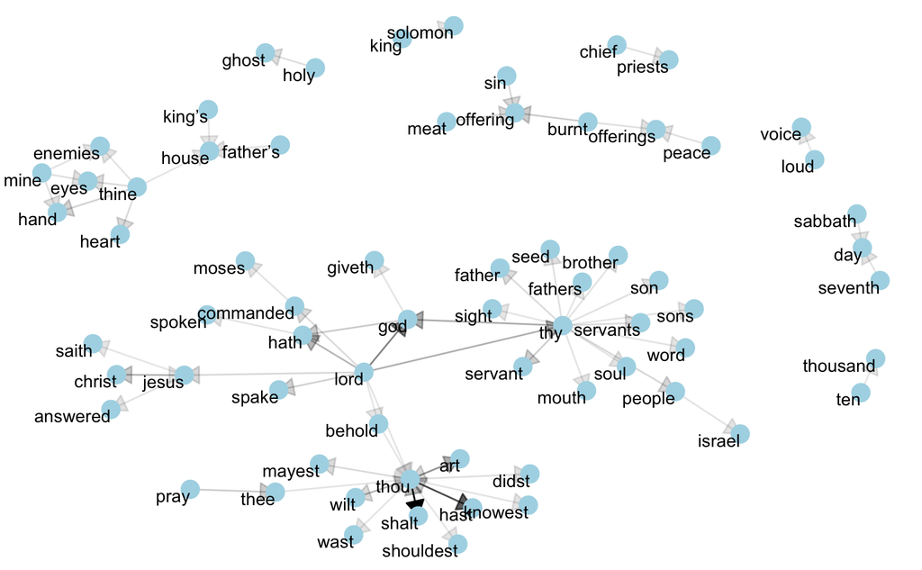

Directed graph of common bigrams in the King James Bible, showing those that occurred more than 40 times

```r
# the King James version is book 10 on Project Gutenberg:
kjv <- gutenberg_download(10)

kjv_bigrams <- kjv %>%
    count_bigrams()

# filter out rare combinations, as well as digits
kjv_bigrams %>%
    filter(n > 40,!str_detect(word1, "\\d"),!str_detect(word2, "\\d")) %>%
    visualize_bigrams()
```

## Counting and correlating pairs of words with the widyr package

We can also look at words that tend to occur together within documents or parts of documents, whether they are next to each other or not.

### Counting and correlating among sections

We look at *Pride and Prejudice* divided into 10-line sections.

```r
austen_section_words <- austen_books() %>%
    filter(book == "Pride & Prejudice") %>%
    mutate(section = row_number() %/% 10) %>%
    filter(section > 0) %>%
    unnest_tokens(word, text) %>%
    filter(!word %in% stop_words$word)

austen_section_words %>%
    slice_sample(n = 10) %>%
    kable(caption = "10-Line Sections from _Pride & Prejudice_")
```

10-Line Sections from *Pride & Prejudice*

| book | section | word |
| --- | --- | --- |
| Pride & Prejudice | 361 | oppose |
| Pride & Prejudice | 11 | twenty |
| Pride & Prejudice | 354 | quarter |
| Pride & Prejudice | 1212 | lizzy |
| Pride & Prejudice | 605 | glancing |
| Pride & Prejudice | 930 | amusement |
| Pride & Prejudice | 462 | idea |
| Pride & Prejudice | 1108 | bingley |
| Pride & Prejudice | 168 | giving |
| Pride & Prejudice | 77 | plain |

```r
# count words co-occuring within sections
word_pairs <- austen_section_words %>%
    pairwise_count(word, section, sort = TRUE)
word_pairs %>%
    slice_max(n, n = 10) %>%
    kable(caption = "Word Pairs per 10-Line Section in _Pride & Prejudice_")
```

Word Pairs per 10-Line Section in *Pride & Prejudice*

| item1 | item2 | n |
| --- | --- | --- |
| darcy | elizabeth | 144 |
| elizabeth | darcy | 144 |
| miss | elizabeth | 110 |
| elizabeth | miss | 110 |
| elizabeth | jane | 106 |
| jane | elizabeth | 106 |
| miss | darcy | 92 |
| darcy | miss | 92 |
| elizabeth | bingley | 91 |
| bingley | elizabeth | 91 |

```r
word_pairs %>%
  filter(item1 == "darcy") %>%
    slice_max(n, n = 10) %>%
    kable(caption = "Word that Co-Occur with 'Darcy' per 10-Line Section in _Pride & Prejudice_")
```

Word that Co-Occur with ‘Darcy’ per 10-Line Section in *Pride & Prejudice*

| item1 | item2 | n |
| --- | --- | --- |
| darcy | elizabeth | 144 |
| darcy | miss | 92 |
| darcy | bingley | 86 |
| darcy | jane | 46 |
| darcy | bennet | 45 |
| darcy | sister | 45 |
| darcy | time | 41 |
| darcy | lady | 38 |
| darcy | friend | 37 |
| darcy | wickham | 37 |

### Pairwise correlation

```r
# we need to filter for at least relatively common words first
word_cors <- austen_section_words %>%
    group_by(word) %>%
    filter(n() >= 20) %>%
    pairwise_cor(word, section, sort = TRUE)

word_cors %>%
    slice_max(correlation, n = 10) %>%
    kable(caption = "Word Pair Correlation per 10-Line Section in _Pride & Prejudice_")
```

Word Pair Correlation per 10-Line Section in *Pride & Prejudice*

| item1 | item2 | correlation |
| --- | --- | --- |
| bourgh | de | 0.9508501 |
| de | bourgh | 0.9508501 |
| pounds | thousand | 0.7005808 |
| thousand | pounds | 0.7005808 |
| william | sir | 0.6644719 |
| sir | william | 0.6644719 |
| catherine | lady | 0.6633048 |
| lady | catherine | 0.6633048 |
| forster | colonel | 0.6220950 |
| colonel | forster | 0.6220950 |

```r
word_cors %>%
  filter(item1 == "pounds") %>%
    slice_max(correlation, n = 10) %>%
    kable(caption = "Word Pair - including 'pounds' - Correlation per 10-Line Section in _Pride & Prejudice_")
```

Word Pair - including ‘pounds’ - Correlation per 10-Line Section in *Pride & Prejudice*

| item1 | item2 | correlation |
| --- | --- | --- |
| pounds | thousand | 0.7005808 |
| pounds | ten | 0.2305758 |
| pounds | fortune | 0.1638626 |
| pounds | settled | 0.1494605 |
| pounds | wickham’s | 0.1415240 |
| pounds | children | 0.1290001 |
| pounds | mother’s | 0.1190593 |
| pounds | believed | 0.0932152 |
| pounds | estate | 0.0889688 |
| pounds | ready | 0.0859704 |
| pounds | particulars | 0.0859704 |

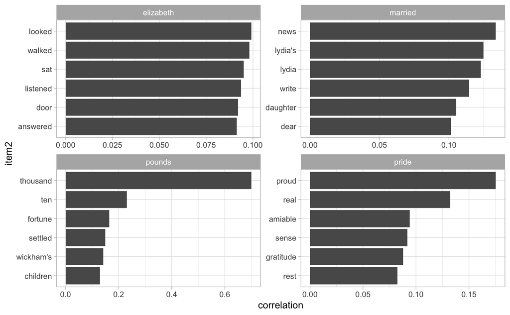

Words from *Pride and Prejudice* that were most correlated with ‘elizabeth’, ‘pounds’, ‘married’, and ‘pride’

```r
word_cors %>%
    filter(item1 %in% c("elizabeth", "pounds", "married", "pride")) %>%
    group_by(item1) %>%
    slice_max(correlation, n = 6) %>%
    ungroup() %>%
    mutate(item2 = reorder(item2, correlation)) %>%
    ggplot(aes(item2, correlation)) +
    geom_bar(stat = "identity") +
    facet_wrap( ~ item1, scales = "free") +
    coord_flip() +
    theme_light()
```

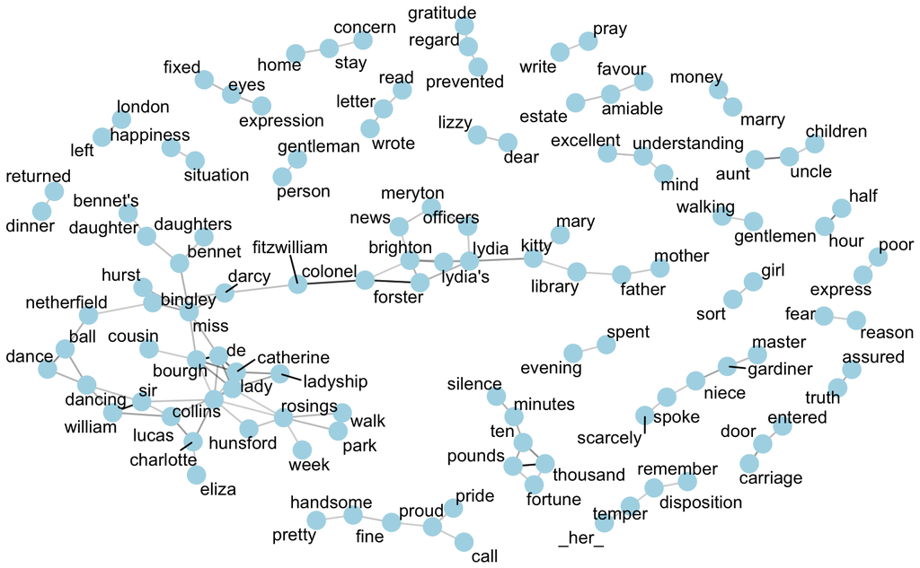

Pairs of words in *Pride and Prejudice* that show at least a .15 correlation of appearing within the same 10-line section

```r
set.seed(2016)

word_cors %>%
    filter(correlation > .15) %>%
    graph_from_data_frame() %>%
    ggraph(layout = "fr") +
    geom_edge_link(aes(edge_alpha = correlation), show.legend = FALSE) +
    geom_node_point(color = "lightblue", size = 5) +
    geom_node_text(aes(label = name), repel = TRUE) +
    theme_void()
```